# Análise de evasão na UFCG

Wesley Nunes Marques Torres

January 18, 2016

# Perguntas a serem respondidas

### Análise das notas dos Alunos da Universidade Federal de Campina Grande(UFCG)

Neste Documentos Foram respondidas duas perguntas sobre o conjunto de dados dos alunos. Que são:

- O índice de desistência está relacionado com a média das notas do curso?
- Qual período possui maior e menor índice de desistência?

> O índice de desistência está relacionado com a média das notas do curso?

Para se avaliar o índice de desistência se faz necessário antes de tudo, identificar onde esta informação está inserida no conjunto de dados, logo, temos a coluna de código de evasão, que é 0 para não abandono e 1 para abandono. Uma forma clara de se identificar isso é pela comparação da mediana de evasão com a mediana dos cursos.

Como existe dados repetidos de metículas, temos primeiramente que agurpar todas as matrículas, pois só assim teremos o número exato de abandonos. Para ser mais justo, será avaliado a proporção de alunos por curso.

Após todo um tratamento de dados, podemos verificar que existe uma relação entre mediana e evasão, pois, quanto menor a mediana do curso, maior será a evasão do curso, como está descrito no gráfico de dispersão abaixo.

```r
table_group_alunos <- alunos %>% group_by(Matricula, Nome_Curso, Cod_Evasao) %>% summarise(cod_evasao = length(Cod_Evasao))
alunos_evasao <- filter(table_group_alunos, Cod_Evasao == 1)

size_por_curso <- alunos %>% group_by(Nome_Curso) %>% summarise(size_alunos = length(Matricula))

evasao_por_curso <- alunos_evasao %>% group_by(Nome_Curso) %>% summarise(size_evasao = length(Matricula))

mediana_cursos <- alunos %>% group_by(Nome_Curso) %>% summarise(mediana_curso = median(Media_Disciplina, na.rm = T))

tabela_evasao_mediana <- select(merge(merge(mediana_cursos,size_por_curso), evasao_por_curso), Nome_Curso, mediana_curso, size_evasao,size_alunos)
```

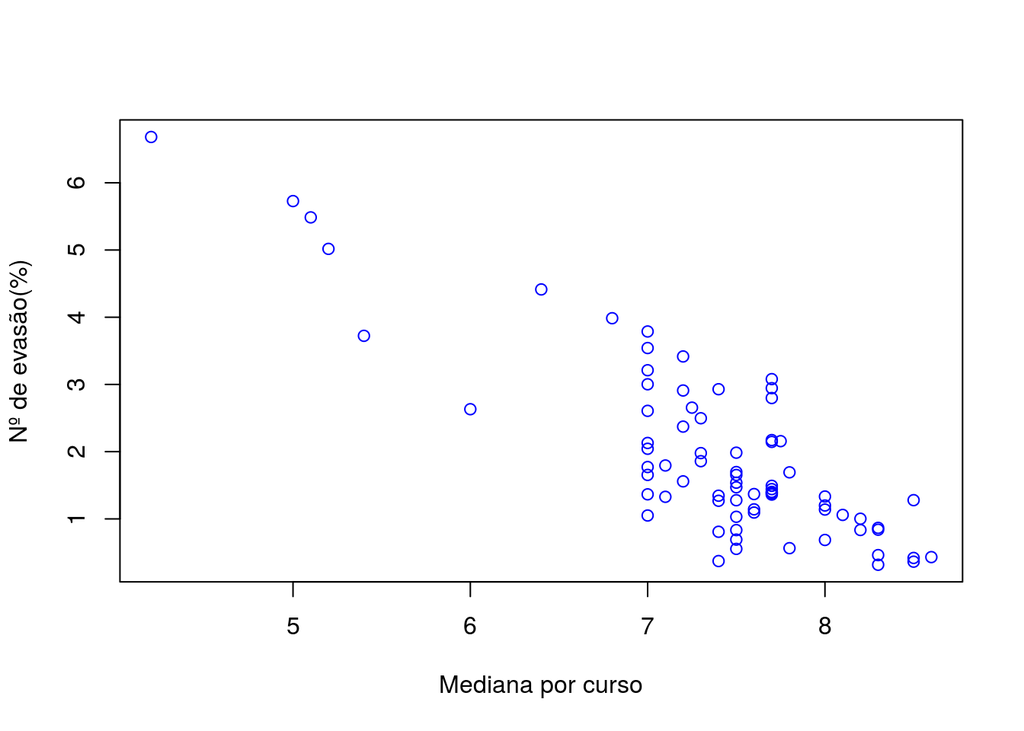

```r
plot(tabela_evasao_mediana$mediana_curso, (tabela_evasao_mediana$size_evasao/tabela_evasao_mediana$size_alunos)*100, type = "p", col = "blue", ylab = "Nº de evasão(%)", xlab = "Mediana por curso")
```

> Qual período possui maior e menor índice de desistência?

Para isso, temos que avaliar o número de desistência em cada período. Antes de tudo, assim como foi feito acima, será usado a proporção de alunos por período. Com isso, no grágico abaixo, vemos que a maior proporção de evasão do curso estão no período de 2012.1 com aproximadamente 10% de evasão. O que possui menor índice de evasão é o período 2006.1, com aproximadamente 3% de evasão.

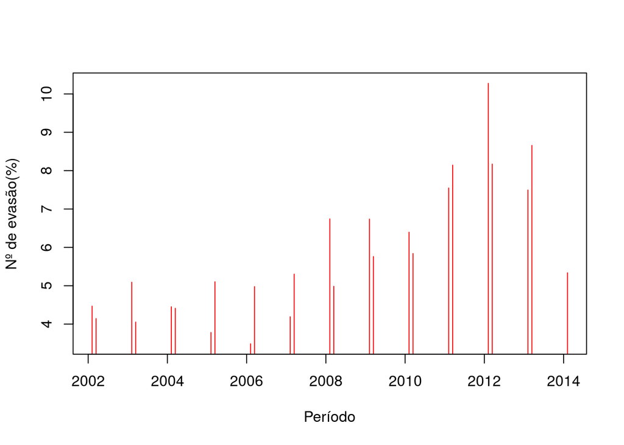

```r
tabela_evasao <- alunos %>% group_by(Periodo, Cod_Evasao) %>% summarise(size_evasao = length(Cod_Evasao))
evasaoPorPeriodo <- filter(tabela_evasao, Cod_Evasao == 1)

size_por_periodo <- alunos %>% group_by(Periodo) %>% summarise(size_alunos = length(Matricula))

tabela_evasao_periodo = merge(evasaoPorPeriodo, size_por_periodo)
plot(tabela_evasao_periodo$Periodo, (tabela_evasao_periodo$size_evasao/tabela_evasao_periodo$size_alunos)*100, type = "h", col = "red", ylab = "Nº de evasão(%)", xlab = "Período")
```